# Git, Github, Github Pages

Carolina Torreblanca

University of Pennsylvania

**Global Development**: Intermediate Topics in Politics, Policy, and Data

PSCI 3200 - Spring 2026

# Logistics

## Final Project Assignments

- Expect feedback on *Research Question and Data* by Wed EOD
- Next deadline is March 5

**Warning**

Late assignments deduct 2 points per day

## Final Project Assignments

| Milestone | Due Date |
| --- | --- |
| [Create a GitHub repository](https://carolina-torreblanca.github.io/psci3200-globaldev-main/assignments/02_gitrepo.html) | Feb 17 |
| [Research Question and Data](https://carolina-torreblanca.github.io/psci3200-globaldev-main/assignments/03_fprqd.html) | Feb 19 |
| [**Research Design**](https://carolina-torreblanca.github.io/psci3200-globaldev-main/assignments/04_fpdesign.html) | Mar 5 |
| [Submit proposal](https://carolina-torreblanca.github.io/psci3200-globaldev-main/assignments/05_fptest.html) | Apr 2 |
| [Submit final project](https://carolina-torreblanca.github.io/psci3200-globaldev-main/assignments/final_project.html) | May 10 |

# Git and Github

## Installing git

1. Open the terminal/command prompt
2. Check if you have git installed

```
git --version
```

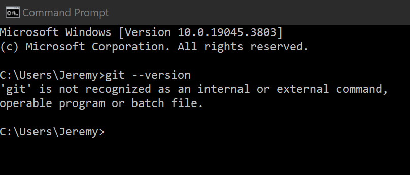

## Installing git

**If yes, consider running an update**

```
git update-git-for-windows
```

## Installing git

**If no, install git**

- [Installation instructions](https://git-scm.com/book/en/v2/Getting-Started-Installing-Git)
  - Download `.exe` and double-click
- Two things to watch for:
  - Adjusting the name of the initial branch: Override the default branch name (select ‘main’)
  - Adjusting your PATH: make sure to select command line and 3rd-party

## Installing git

[figure not shown]

## Installing git

[figure not shown]

## Installing git

[figure not shown]

## Installing git

[figure not shown]

## Installing git

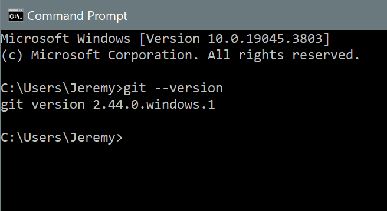

## git Basics

**Git is a version control program**, so you can avoid…

[output not shown]

**Version control allows you to precisely track changes**

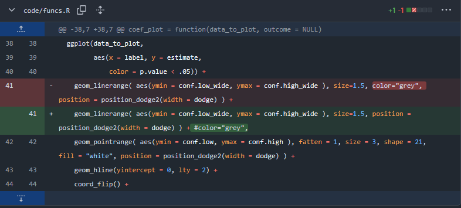

## git Basics

**Show off your productivity**

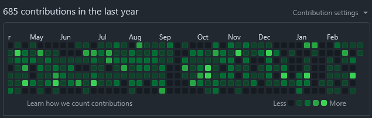

**Share projects publicly**

[figure not shown]

## git Basics

**Git hosts data and code**

- “Remote” (`main`) on github.com
- “Local” on your harddrive(s) in a designated folder
- Resembles Dropbox/Drive synch + Version history
- Many advantages; a few disadvantages

## git Basics

**Version control**

- Precisely tracks changes
- Revert to old versions
- Avoid devastating loss
- Note: everything is public by default

## git Basics

**Collaboration**

- When you collaborate, it’s clear who to blame
- Simultaneous editing can cause challenges

[figure not shown]

- Please don’t create conflicts *with yourself*

## git Basics

**Basic commands**

- `git pull origin main`
- `git add .`
- `git commit -m "describe your changes or vent frustration"`
- `git push origin main`
- `git pull origin main`

## git Basics

**Git can be complicated**

- Often used for serious software development
- Branches, conflicts, merges, rebase
- Massive online community to help with more sophisticated use

## Connect your GitHub account

1. Open the terminal and enter the code below
2. Replace `"Your Name"`and `"yourname@email.edu"` with your name/email used to sign up for GitHub
3. Run the code

```
git config --global user.name "Your Name"
git config --global user.email "yourname@email.edu"
```

## Connect your GitHub account

**Check that the confirmation worked**

```
git config --list
```

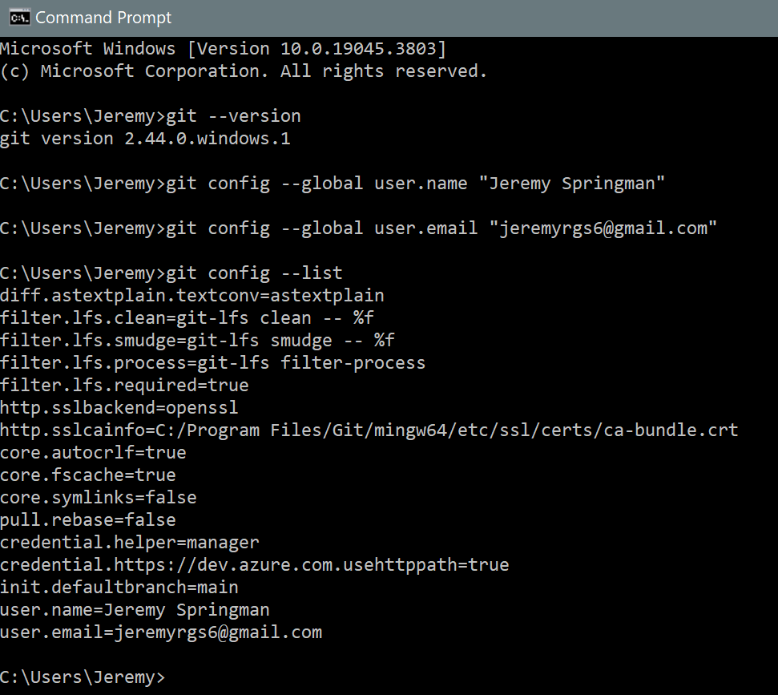

## Install a git client

1. Download [GitHub Desktop](https://desktop.github.com/) `.exe`
2. Double click the `.exe`

[figure not shown]

## Install a git client

[figure not shown]

## Clone your repo

[figure not shown]

## Clone your repo

[figure not shown]

## Clone your repo

[figure not shown]

## Commit changes

[figure not shown]

## Push to your repo

[figure not shown]

## Pull from your repo

[figure not shown]

# Github Pages

## Create a website

**Moving to RStudio**

- File $\rightarrow$ New Project $\rightarrow$ New Directory $\rightarrow$ Quarto Website

[figure not shown]

## Create a website

[figure not shown]

## Create a website

**Change output director to `docs`**

[figure not shown]

## Publish to Github pages

- Keep a repository of your website
- Push changes to your website via Github
- See changes almost instantly

## Publish to Github pages

- Publish local git repo to github.com
- Uncheck ‘Keep this code private’
- Open repo on github.com
- Settings $\rightarrow$ Pages (left-sidebar)

## Publish to Github pages

[figure not shown]

## Publish to Github pages

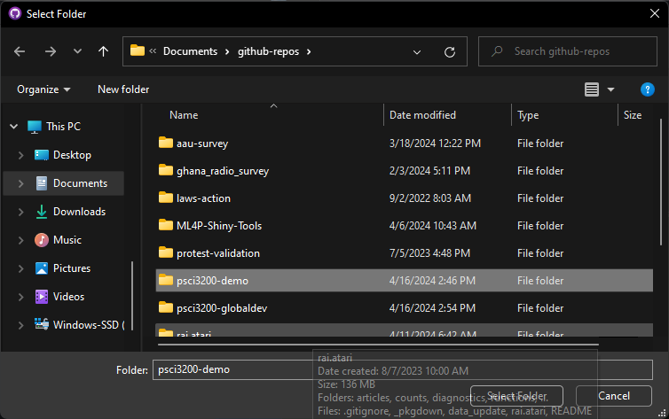

## Publish to Github pages

[figure not shown]

## Publish to Github pages

[figure not shown]

## Publish to Github pages

[figure not shown]

## Publish to Github pages

[figure not shown]

## Host Your Final Project

- Delete `_site` folder (now its using `docs`)
- Create `data` folder to store your dataset
- Add final project `.qmd` file to your repo (or drop it into `index.qmd`)
- Use `_quarto.yml` to add new pages to navigation bar
- Render `index.qmd`; confirm that other pages have been rendered
- Push commit and check that the website updated

https://carolina-torreblanca.github.io/psci3200-globaldev-main/